# 6_Predicting numerical data - regression methods

# 第６章 数値データを予測する―回帰法

本章では数値データ間の関係を予測するための手法を学ぶ。内容は次の通り。

- 回帰で使われている基本的な統計学の原理
- 回帰分類のためのデータの前処理と、回帰モデルの推定と解釈
- 回帰木及びモデル木と呼ばれるハイブリッド手法

```r
# ライブラリの読み込み
if(! require(tidyverse)){
    install.packages('ridyverse', quiet = TRUE)
}
library(tidyverse)
```

## 6.1 回帰を理解する

回帰の目的は、従属変数（dependent variable）と独立変数（independent variable）の関係を明らかにすることである。

回帰方程式は、傾き切片形と同じような直線を使ってデータをモデル化する。回帰分析は、過去の事象をモデル化することと、そのモデルを使って未来の事象を予測することについて利用できる。

具体的なユースケースをいくつかあげる。

- 観測された属性に基づく集団や個体のばらつきの調査。この分析は、経済学、社会学、心理学、物理学、生態学の分野での科学的調査に利用される
- 事象と反応の間の因果関係の定量化。医薬品の治験、高額の安全性検査、市場調査などに利用される。
- 基地の基準に照らして未来の挙動を予測するために利用できるパターンの特定。保険請求、自然災害の被害、選挙結果、犯罪率の予測に利用される。

### 6.1.1 単回帰

単回帰モデルは、従属変数と単一の独立変数との関係を定義する。この定義には、次の式によって表される直線を使う。
$$y = \alpha + \beta x$$

この式は傾き切片形の式と同じである。切片$\alpha$は直線が$ｙ$軸と交差する点を表し、傾き$\beta$は$x$の値が増えるたびに$y$がどのくらい変化するのかを表す。

上式の$\alpha$と$\beta$の推定値は一般に$a$と$b$を使って記述する。

### 6.1.2 最小二乗法による推定

$\alpha$と$\beta$の最適な推定値の特定には、**最小二乗法**という推定法を使った。最小二乗回帰の目的は、次の式を最小化することとして表現される。

$$\sum{(y_i - \hat{y_i})^2} = \sum{e_i^2}$$

また、$a$の解は$b$の値によって決まる。$a$の値を求める式は次のようになる。

$$a=\bar{y}-b\bar{x}$$

検証用のデータとして、スペースシャトルの打ち上げデータを使用する。

```r
# ファイルの読み込み
launch <- read.csv('https://raw.githubusercontent.com/dataspelunking/MLwR/master/Machine%20Learning%20with%20R%20(3rd%20Ed.)/Chapter06/challenger.csv', stringsAsFactors = TRUE)

launch %>% head(n = 3)
```

|  | distress_ct | temperature | field_check_pressure | flight_num |
| --- | --- | --- | --- | --- |
| 1 | 0 | 66 | 50 | 1 |
| 2 | 1 | 70 | 50 | 2 |
| 3 | 0 | 69 | 50 | 3 |

上記データを使い独立変数 temparature 従属変数が distress_ct とすると傾き$b$の値はRの関数covとvarを使って推定できる。

```r
b <- cov(launch$temperature, launch$distress_ct) / var(launch$temperature)
b
```

```
[1] -0.04753968
```

そして、この$b$の値とmean関数を使って$a$の値を推定できる。

```r
a <- mean(launch$distress_ct) - b * mean(launch$temperature)
a
```

```
[1] 3.698413
```

### 6.1.3 相関

2つの変数の間の**相関**（correlation）は、それらの関係がどれくらい直線的であるかを数値化したものである。修飾子が付かない単なる「相関」は、一般に、**ピアソンの相関係数**（Pearson correlation coefficient）を指している。

ピアソンの相関係数は次の式によって定義される。

$$\rho_{x,y}=Corr(x,y)=\frac{Cov(x,y)}{\rho_x\rho_y}$$

この式を使って、スペースシャトルの打ち上げ時の気温と破損したOリングの数との相関を計算できる。

```r
r <- cov(launch$temperature, launch$distress_ct) / (sd(launch$temperature) * sd(launch$distress_ct))

r
```

```
[1] -0.5111264
```

相関関数corでも同様の結果が得られる

```r
cor(launch$temperature, launch$distress_ct)
```

```
[1] -0.5111264
```

このデータにおけるスペースシャトルの打ち上げ時の気温と破損したOリングの一人の相関は-0.51となった。これは比較的強い負の線形連関があることを示している。

相関の強さを解釈するための目安は様々ある。例えば、0.1～0.3の値を「弱い」、0.3～0.5の値を「中くらい」、0.5を超える値を「強い」と判断するルールもある（負の相関の範囲も同様）。しかし、目的によっては、これらの閾値が厳しすぎるまたは緩すぎることもある。多くの場合、相関はコンテキストの中で解釈する必要がある。人間が関わっているデータでは、0.5の相関が極めて高いと見なされるとしても、機械的なプロセスで生成したデータでは、0.5の相関は非常に弱いかもしれない。

> 【Tips】

> 「相関は因果関係を含意しない」という表現を聞いたことがあるかもしれない。この表現の根底にあるのは、相関によって表されるのは２つの変数間の関連性だけで、未観測の説明が他にも存在するかも知れないという事である。例えば、平均余命と一日あたりの映画鑑賞時間との間に強い相関があったとしても、「若者のほうが映画をよく観るが、死亡する可能性は低い」という説明を排除できない限り、医者が「映画をもっと観るべきだ」と勧めることはない。

### 6.1.4 重回帰

現実のほとんどの分析では、独立変数は１つだけではない。したがって、ほとんどの数値予測タスクでは、重線形回帰（重回帰）を使うことになる。次の表に重回帰の長所と短所をまとめた。

長所

短所

- 数値データのモデル化に最もよく使われている
- ほぼすべてのモデル化タスクに適応できる
- 独立変数（特徴量）と従属変数の関係の大きさと強さを推定する
- データについて強い仮定をおく
- モデルの形状をユーザーが事前に指定しなければならない
- 欠損値に対処しない
- 数値特徴量にしか対応しないため、カテゴリ値の特徴量については前処理が必要
- モデルを理解するには統計学の知識が必要

データを読み込みます。

```r
launch <- read.csv('https://raw.githubusercontent.com/dataspelunking/MLwR/master/Machine%20Learning%20with%20R%20(3rd%20Ed.)/Chapter06/challenger.csv', stringsAsFactors = TRUE)
```

```r
reg <- function(y, x){
    x <- as.matrix(x)
    x <- cbind(Intercept = 1, x)
    b <- solve(t(x) %*% x) %*% t(x) %*% y
    colnames(b) <- 'estimate'
    print(b)
}
```

```r
str(launch)
```

```
'data.frame':   23 obs. of  4 variables:
 $ distress_ct         : int  0 1 0 0 0 0 0 0 1 1 ...
 $ temperature         : int  66 70 69 68 67 72 73 70 57 63 ...
 $ field_check_pressure: int  50 50 50 50 50 50 100 100 200 200 ...
 $ flight_num          : int  1 2 3 4 5 6 7 8 9 10 ...
```

```r
cat('単回帰分析')
```

```
単回帰分析
```

```r
reg(y = launch$distress_ct, x = launch %>% select(temperature))
```

```
               estimate
Intercept    3.69841270
temperature -0.04753968
```

```r
cat('\n重回帰分析')
```

```
重回帰分析
```

```r
reg(y = launch$distress_ct, x = launch %>% select(-distress_ct))
```

```
                         estimate
Intercept             3.527093383
temperature          -0.051385940
field_check_pressure  0.001757009
flight_num            0.014292843
```

この重回帰分析の結果から、温度が1${}^\circ$F 上昇するごとに0.05ほど少なくなると推定している。

新た追加された2つの独立変数もOリングのは破損数の推定に寄与している。field_check_pressure変数は打ち上げ前の検査でOリングに加えられた圧力の強さを示している。検査圧はもともと50psiだったが、一部の打ち上げでは100psiと200psiに引き上げられており、Oリングのエロージョンの引き金になったのではという見方もあった。この係数は（かなり小さいもの）正の値であり、この仮説を裏付ける小さな証拠となる。flight_numはスペースシャトルの運用期間を考慮にいれるための変数である。スペースシャトルはフライトのたびに劣化し、部品がもろくなったり故障しやすくなったりすることがある。flight_numも正の相関を持つのはこの事実を反映している可能性がある。

## 6.2 例：線形回帰を使って医療費を予測する

この分析の目標は、患者のデータを使ってそうしたセグメントの絵費金医療費を推定することである。こちらの推定値は、予想される医療費に基づいて年なkん保険料を調整するための保険数理表の作成に利用できるはずだ。

### ステップ1：データを収集する

```r
# データの読み込み
insurance <- read.csv('https://raw.githubusercontent.com/dataspelunking/MLwR/master/Machine%20Learning%20with%20R%20(3rd%20Ed.)/Chapter06/insurance.csv', stringsAsFactors = TRUE)

insurance %>% head(n=3)
```

|  | age | sex | bmi | children | smoker | region | expenses |
| --- | --- | --- | --- | --- | --- | --- | --- |
| 1 | 19 | female | 27.9 | 0 | yes | southwest | 16884.92 |
| 2 | 18 | male | 33.8 | 1 | no | southeast | 1725.55 |
| 3 | 28 | male | 33.0 | 3 | no | southeast | 4449.46 |

insurance.csvファイルには、現在医療保険に加入している患者のデータが1,338件含まれている。これらのデータは間者hの属性と保険で支払われる年間医療費を表す特徴量で構成されている。

- age：加入者本人の年齢を示す整数（一般に医療費が無料となる65歳以上を除く）
- sex：加入者の性別（male または female）
- bmi：ボディマス指数（BMI）。身長と体重から算出さた肥満度を表すもので、体重（Kg ）を身長（ m）の二乗で割った値である。BMI海苔装置は18.5～24.9
- children：医療保険の対象となる子／被扶養者の人数を表す整数
- smoker：加入者が日常的に喫煙するかどうかを示すカテゴリ値の特徴量（yesまたはno）
- Region：加入者の居住地（northeast、southeast、southwest、northwestの4つに分割）

### ステップ2：データの調査と前処理

```r
str(insurance)
```

```
'data.frame':   1338 obs. of  7 variables:
 $ age     : int  19 18 28 33 32 31 46 37 37 60 ...
 $ sex     : Factor w/ 2 levels "female","male": 1 2 2 2 2 1 1 1 2 1 ...
 $ bmi     : num  27.9 33.8 33 22.7 28.9 25.7 33.4 27.7 29.8 25.8 ...
 $ children: int  0 1 3 0 0 0 1 3 2 0 ...
 $ smoker  : Factor w/ 2 levels "no","yes": 2 1 1 1 1 1 1 1 1 1 ...
 $ region  : Factor w/ 4 levels "northeast","northwest",..: 4 3 3 2 2 3 3 2 1 2 ...
 $ expenses: num  16885 1726 4449 21984 3867 ...
```

```r
summary(insurance$expenses)
```

```
   Min. 1st Qu.  Median    Mean 3rd Qu.    Max.
   1122    4740    9382   13270   16640   63770
```

平均値が中央値よりも大きいため、医療費の分布が右歪曲であることがわかる。

更にヒストグラムを確認する。

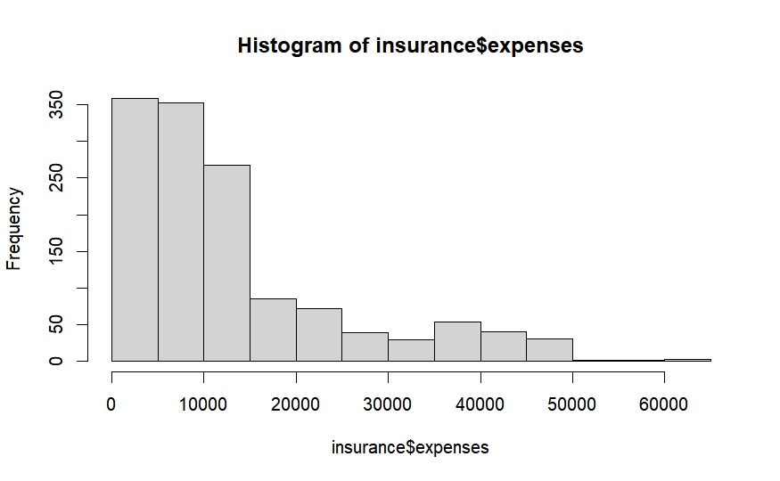

```r
hist(insurance$expenses)
```

カテゴリ変数になっている region を確認する。

```r
table(insurance$region)
```

```
northeast northwest southeast southwest
      324       325       364       325
```

#### 特徴量の間の関係を調べる：相関行列

insuranceデータフレームの4つの数値特徴量から相関行列を作成するには、cor関数を使う。

```r
insurance %>% select(age, bmi, children, expenses) %>% cor()
```

```
               age        bmi   children   expenses
age      1.0000000 0.10934101 0.04246900 0.29900819
bmi      0.1093410 1.00000000 0.01264471 0.19857626
children 0.0424690 0.01264471 1.00000000 0.06799823
expenses 0.2990082 0.19857626 0.06799823 1.00000000
```

#### 特徴量の間の関係を可視化する：散布図行列

散布図行列は、単に散布図をグリッド上に並べたもので、3つ以上の特徴量の間でパターンを検出するために使われる。一度に可視化できる特徴量は２つだけなので、真に多次元化の可視化であるとは言えない。それでも、データの相互関係がだいたいどのようなものであるかが分かる。

R環境にデフォルトで実装されているpairs関数で可視化してみる。

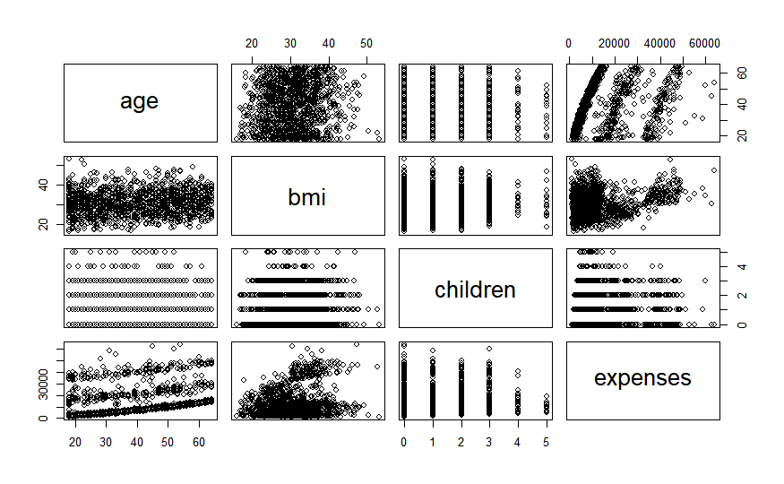

```r
insurance %>% select(age, bmi, children, expenses) %>% pairs()
```

もう少し詳しく見るために psych パッケージのpairs.panels関数を使う。

```r
if(! require(psych)){
    install.packages('psych', quiet = TRUE)
}
library(psych)
```

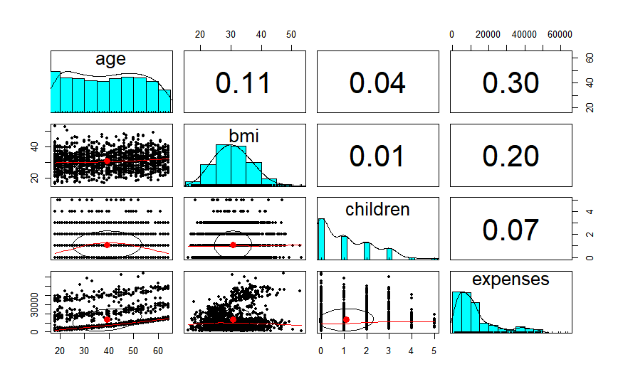

```r
insurance %>% select(age, bmi, children, expenses) %>% pairs.panels()
```

各散布図に描かれている楕円形の要素は**相関楕円**（correlation ellipse）であり、相関の強さを可視化している。楕円が引き伸ばされているほど、相関が強いことを意味する。bmiとchildrenの散布図にあるような正円に近い楕円は、相関は非常に弱いことを意味する（この場合は0.01）。

ageとexpensesの散布図の楕円は、より強い相関を反映してかなり引き伸ばされている（値は0.30）。楕円の中心にある丸印は、x軸とy軸の変数の平均値を反映している。

散布図に描かれている曲線は**Loess曲線**（loess curve）と呼ばれ、x軸とy軸の変数の一般的な関係を表す。たとえば、ageとchildrenのLoess曲線はUを逆さにした形をしており、ピークは中年層にある。つまり、高齢層や若年層のほうが中年層よりも保険プランに含まれている子供の数が少ないことを示している。この傾向は線形ではないため、相関だけでは、この関係を推測できなかった可能性がある。これに対し、ageとbmiのLoess曲線は少しずつ上に向かっており、年齢とともに体重が増えることを示唆している。

### ステップ3：モデルを 訓練する

```r
ins_model <- lm(expenses ~ age + sex + bmi + children + smoker + region, data = insurance)
```

すべての特徴量（モデル式にすでに含まれているものを除く）を指定する場合はピリオド（.）が使えるため、このコマンドを次のように書き換える事もできる。

```r
ins_model <- lm(expenses ~ ., data = insurance)
```

モデルを構築した後は、モデルオブジェクトの名前を入力するだけで、β係数の推定値を確認できる。

```r
print(ins_model)
```

```
Call:
lm(formula = expenses ~ ., data = insurance)

Coefficients:
    (Intercept)              age          sexmale              bmi         children        smokeryes  regionnorthwest  regionsoutheast  regionsouthwest
       -11941.6            256.8           -131.4            339.3            475.7          23847.5           -352.8          -1035.6           -959.3
```

カテゴリ変数の場合、最初のカテゴリが基準グループとなる。このモデルでは、sexfemale、smokerno、regionnortheastの3つの変数が自動的に確保され、北東地域に住む女性の非喫煙者が基準グループとなる。したがって、残りの項目を平均すると、男性は女性に比べて年間医療費が131.40ドル少なく、喫煙者は非喫煙者に比べて年間医療費が23,847.50ドル多い。このモデルに含まれている他の３つの地域の係数は負の値であり、平均すると、４つの地域の中で基準グループ（regionnortheast）の年間医療費が最も高い傾向にあることを示唆している。

> 【Tips】

> デフォルトでは、Rは因子変数の最初のレベルを基準レベルにする。別のレベルを基準レベルにしたい場合は、relevel関数を使って基準レベルを明示的に指定できる。

### ステップ4：モデルの性能を評価する

ins_modelと入力したときに出力されたパラメータの推定値から、独立変数が従属変数にどのような影響を与えているのかはわかるが、このモデルがデータにどれくらい適合しているかは全くわからない。モデルの性能を評価するために、このモデルでsummaryコマンドを実行する。

```r
summary(ins_model)
```

```
Call:
lm(formula = expenses ~ ., data = insurance)

Residuals:
     Min       1Q   Median       3Q      Max
-11302.7  -2850.9   -979.6   1383.9  29981.7

Coefficients:
                Estimate Std. Error t value Pr(>|t|)
(Intercept)     -11941.6      987.8 -12.089  < 2e-16 ***
age                256.8       11.9  21.586  < 2e-16 ***
sexmale           -131.3      332.9  -0.395 0.693255
bmi                339.3       28.6  11.864  < 2e-16 ***
children           475.7      137.8   3.452 0.000574 ***
smokeryes        23847.5      413.1  57.723  < 2e-16 ***
regionnorthwest   -352.8      476.3  -0.741 0.458976
regionsoutheast  -1035.6      478.7  -2.163 0.030685 *
regionsouthwest   -959.3      477.9  -2.007 0.044921 *
---
Signif. codes:  0 ‘***’ 0.001 ‘**’ 0.01 ‘*’ 0.05 ‘.’ 0.1 ‘ ’ 1

Residual standard error: 6062 on 1329 degrees of freedom
Multiple R-squared:  0.7509,    Adjusted R-squared:  0.7494
F-statistic: 500.9 on 8 and 1329 DF,  p-value: < 2.2e-16
```

summaryコマンドは次の情報を出力する。

1. **残差**  
   Residualsセクションは予測値の誤差に関する要約統計量を提供する。この出力には、見るからに大きい誤差が含まれている。残差は正解値から予測値を引いた値に等しいため、誤差の最大値が29981.7であることは、少なくとも1つの観測値について、モデルが医療費を30,000ドル近くも低く見積もっていることを示唆している。一方で、誤差の50%は1Q（第1四分位数）と3Q（第3四分位数）の間に含まれており、予測値の大部分が正解地よりも2,850.90ドル高い金額から正解値よりも、1383.90ドル低い金額の間に含まれていたことがわかる。
2. **p値**  
   回帰係数の推定値ごとに**p値**（p-value）が出力されている。p値は$Pr(>|r|)$で示されている値であり、推定値に照らして係数の正解値が0になる確率を表す。p値が小さければ、係数の正解値が0になる可能性は非常に低い。つまり、その特徴量が従属変数と無関係である。p値の一部についている***は、その推定値によって満たされる**有意水準**（significance level）を示す脚注に対応している。有意水準はモデルの構築前に選択された閾値であり、単なる偶然によるものではない「現実の」発見であることを示すために使われる。有意水準に満たないp値は「統計学的に有意」であると見なされる。統計学的に有意な項が少ないモデルは懸念の全員になることがある。そのモデルに使われている特徴量の説明変数としての重要度が非常に低いということになるからだ。このモデルには優位性の高い特徴量がいくつか含まれており、論理的な方法で 結果に影響を与えているように見える。
3. **寄与率**  
   **寄与率**（multiple R-squared）は、モデル全体として従属変数の値をどれくらいうまく説明しているかを表す指数であり、**決定係数** （coefficent of determination）とも呼ばれる。この値が1.0に近づくほどモデルがデータを完全に説明するようになるという点では、相関係数に似ている。寄与率の値は0.7509なので、このモデルが従属変数の部；んさんの75%近くを説明していることがわかる。特徴量の数が多いモデルでは常に説明できる分散も増え、寄与率が1に近づくことになる。そこで、独立変数の数が多いモデルにペナルティを与えて寄与率を補正したのが**調整済み寄与率**（adjusted R-squared）である。このような補正は独立変数（説明変数）の数が異なるモデルの性能を比較するのに役立つ。

上記の3つの性能指標を見る限り、このモデルの性能はかなりよい。現実のデータに基づく 回帰モデルでは、寄与率がかなり小さな値になることも珍しくないため、実際のところ0.75は かなり良い数字である。一部の誤差の大きさが少し気がかりだが、医療費データの性質を考え れば意外なことではない。しかし、モデルを少し異なる方法で構築すれば、モデルの性能を 改善できるかもしれない。

### ステップ5：モデルの性能を向上させる

他の機械学習アプローチに対する回帰モデルの主な違いは、特徴量の選択とモデルの仕様を一般にユーザが決めるという点にある。したがって、特徴量と従属変数の関係についての知識があれば、その情報をモデルの仕様に反映させモデルの性能を改善できることがある。

#### モデルに非線形関係を追加する

線形回帰では、独立変数と従属変数の関係が線形であると仮定するが、この仮定が常に成り立つとは限らない。たとえば、年齢が医療費に与える影響は、すべての年齢値に渡って一定であるとは限らない。高齢者の医療費は不釣り合いなほど高くなることがある。 一般的な回帰式が次の形式を取る。
$$y = \alpha + \beta_1x$$
非線形関係を考慮するには、回帰式に高次の項を追加することで、モデルを多項式として扱えばよい。 実質的には、次のような関係をモデル化することになる。
$$y = \alpha + \beta_1x + \beta_2x^2$$
これらの2つのモデルの違いは、$\beta$をもう1つ推定することで$x^2$の項の影響を補足することにある。このようにすると、ageの影響をあageの二条の関数として表せるようになる。 ageの非線形性をモデルに追加するには、新しい変数age2を作成すればよい。

```r
insurance <- insurance %>% mutate(age2 = age^2)
insurance %>% select(age, age2) %>% head(n = 5)
```

|  | age | age2 |
| --- | --- | --- |
| 1 | 19 | 361 |
| 2 | 18 | 324 |
| 3 | 28 | 784 |
| 4 | 33 | 1089 |
| 5 | 32 | 1024 |

続いて、新しいモデルを構築するときに、expenses ~ age + age2 というモデル式を使ってage と age2 を lm関数に追加する。

#### 数値特徴量を二値の変数に変換する

特徴量影響が影響力を持つのは特定の閾値に達したときだけで、その影響力は累積的ではないと にらんでいるとしよう。たとえば、bmiが医療費に与える影響が正常な体重の範囲では ゼロだったとしても、肥満（値が30以上）の場合は医療費の上昇に強い影響を与えているかもしれない。 この関係をモデル化するために、二値の肥満指標変数を作成する。この変数の値は、bmiの値が30以上の場合は1、30未満の場合は0である。この二値変数の $\beta$係数の推定値は、（bmiの値が30未満の人を基準として） bmiの値が30以上の場合に医療費に与える平均的な影響の大きさを示すものになる。

この変数はifelse関数を使って作成できる。この関数は、ベクトルの要素ごとに指定された条件をテストし、その条件が満たされたかどうかに基づいて値を返す。bmiの値が30以上の場合は1を返し、それ以外の場合は0を返す変数は次のようになる。

```r
insurance <- insurance %>% mutate(bmi30 = ifelse(.$bmi >= 30, 1, 0))
```

あとは、このbmi30変数を新しいモデルに追加すればよい。BMIの線形の影響とは別に肥満の影響があると考えるかどうかに応じて、この変数を単に追加するか、元のbmi変数の代わりに使うことができる。

> 【Tips】

> 変数をツキカするかどうかで悩んでいる場合の常套手段は、変数追加してp値を調べることである。ヘンスが統計学的に有利でなければ、あとからこの変数を除外する根拠となる。

#### モデルに相互作用を追加する

ここまでは、従属変数への寄与をもっぱら特徴量ごとに検討してきた。しかし、特徴量の特定の組み合わせが従属変数に影響を与えることもある。たとえば、喫煙と肥満はどちらも悪影響を及ぼす可能性があるが、喫煙と肥満の複合的な影響のほうが、それぞれの影響を足し合わせたものよりも大きいと捉えられる場合がある。 ２つの特徴量が複合的な影響力を持つことを相互作用（interaction）と呼ぶ。２つの特徴量に相互作用があると推測される場合は、それらの相互作用をモデルに追加して、実際に相互作用があるかどうかを確かめることができる。これをRのモデル式で指定するには、肥満指標（bmi30）と喫煙指標（smoker）の相互作用を追加するには、`expeses ~ bmi30 * smoker`というモデル式を記述する。 *演算子は、`expenses ~ bmi300 + smokeryes + bmi30:smokeryes`をモデル化するための省略表記である。この展開式に含まれている:演算子は、bmi30:smokeryesが2つの変数の相互作用であることを示している。また、この展開式には、bmi30とsmokeryesの相互作用に加えて、これらの変数も自動的に含まれている。

> 【Tips】

> 相互作用を持つ変数もそれぞれにモデルに追加する必要がある。そうでなければ、相互作用モデルに追加すべきではない。常に*演算子を使って相互作用を追加するなら問題はない。その場合は、必要な変数が自動的に追加されるからだ。

#### すべてを組み合わせて回帰モデルを改善する

医療費と患者の属性との関係に関する知識を活かして、回帰式を改善した方法をまとめる。

- 年齢に関する非線形項の追加
- 肥満を表す二値変数の作成
- 肥満と喫煙の相互作用の追加

先程と同様にlm関数を使ってモデルを訓練するが、今回は新たに作成した変数と相互作用の項を追加する。

```r
ins_model2 <- lm(expenses ~ age + age2 + children + bmi + sex +
                  bmi30*smoker + region, data = insurance)

summary(ins_model2)
```

```
Call:
lm(formula = expenses ~ age + age2 + children + bmi + sex + bmi30 *
    smoker + region, data = insurance)

Residuals:
     Min       1Q   Median       3Q      Max
-17297.1  -1656.0  -1262.7   -727.8  24161.6

Coefficients:
                  Estimate Std. Error t value Pr(>|t|)
(Intercept)       139.0053  1363.1359   0.102 0.918792
age               -32.6181    59.8250  -0.545 0.585690
age2                3.7307     0.7463   4.999 6.54e-07 ***
children          678.6017   105.8855   6.409 2.03e-10 ***
bmi               119.7715    34.2796   3.494 0.000492 ***
sexmale          -496.7690   244.3713  -2.033 0.042267 *
bmi30            -997.9355   422.9607  -2.359 0.018449 *
smokeryes       13404.5952   439.9591  30.468  < 2e-16 ***
regionnorthwest  -279.1661   349.2826  -0.799 0.424285
regionsoutheast  -828.0345   351.6484  -2.355 0.018682 *
regionsouthwest -1222.1619   350.5314  -3.487 0.000505 ***
bmi30:smokeryes 19810.1534   604.6769  32.762  < 2e-16 ***
---
Signif. codes:  0 ‘***’ 0.001 ‘**’ 0.01 ‘*’ 0.05 ‘.’ 0.1 ‘ ’ 1

Residual standard error: 4445 on 1326 degrees of freedom
Multiple R-squared:  0.8664,    Adjusted R-squared:  0.8653
F-statistic: 781.7 on 11 and 1326 DF,  p-value: < 2.2e-16
```

最初のモデルと比較すると、寄与率が0.75から0.87に改善されている。 同様に、モデルが少し複雑になったことを考慮するための調整済み寄与率も0.75から0.87に 改善されている。このモデルは医療費の分散の87%を説明できている。それに加えて、モデルの関数形 についての論理の論理も検証されたようである。高次の項age2は統計学的に有意であり、肥満指標 bmi30も統計学的に有意である。肥満と喫煙の相互作用bmi30:smokeryesは多いな影響力を持つようである。 喫煙だけでも医療費が13,404ドルに増えるが、肥満と喫煙では医療費が19,810ドルも増える。このことは、 肥満が原因の疾患が喫煙によって悪化することを示唆しているかもしれない。

> 【Tips】

> 回帰モデルの価値は、プロセスを正確に捉えるかどうかではなく、予測が正確かどうかで決まる。しかし、回帰モデルの係数から確実な予測を行いたい場合は、回帰の仮定が覆されていないことをテストで診断する必要がある。

#### 回帰モデルを使って予測を行う

回帰係数の推定値とモデルの統計量を調べた後は、このモデルを使って医療保険プランに将来加入する人の医療費を予測することもできる。予測をどのように行うのかをぐち的に示すために、まず、predict関数を使ってモデルを最初の訓練データに適用してみよう。

```r
insurance <- insurance %>% mutate(pred = predict(ins_model2, .))
```

このコマンドを実行すると、予測値がpredという新しいベクトルとしてinsuranceデータフレームに保存される。 続いて、医療費の予測値と正解値の相関係数を計算する。

```r
cor(insurance$pred, insurance$expenses)
```

```
[1] 0.9307999
```

相関係数の0.93という値は、予測値と正解値の間に非常に強い線形関係があることを示唆している。 これはよい兆候であるーモデルの正解率が高いと考えられるからだ。また、この結果を散布図で調べて見るのも 効果的である。この関係をプロットし、切片0、傾き1の対角線を引く。col、lwd、ltyつのパラメータはそれぞれ線の色、幅、種類をしている

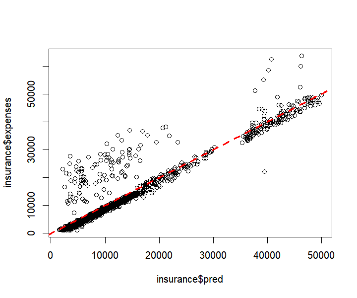

```r
plot(insurance$pred, insurance$expenses)
abline(a = 0, b = 1, col = 'red', lwd = 3, lty = 2)
```

対角線よりも上にある点は、実際の医療費が予測値を上回ったケースを表している。立っ各線よりも下にある点は、医療費が予測値を下回ったケースである。医療費かが予測を大きく上回っている加入者の数は、医療費が予測を少し下回っている大多数の加入者に見合うほど少ない事がわかる。 ここで、医療保険プランの新しい加入者の医療費を予測したいとしよう。異旅費を予測するには、加入者候補のデータを含んだデータフレームをpredict関数に渡さなければならない。加入者の数が多い場合は、CSVファイルを作成してRに読み込むことを検討したほうがよいだろう。加入者の数が少ない場合は、predict関数の呼び出し時にデータフレームを作成すればよい。たとえば、30歳、肥満、非喫煙者、子供2人、北東地域在住の男性の医療費を予測するコマンドは次のようになる。

```r
predict(ins_model2,
        data.frame(age = 30, age2 = 30^2, children = 2, bmi =30,
                   sex = 'male', bmi30 = 1, smoker = 'no', region = 'northeast'))
```

```
       1
5973.774
```

医療保険会社は、この値をもとに、この加入者グループの損益分岐点を年間6,000ドル（月額500ドル）に設定する必要があるかもしれない。predict関数を同じように使って、女性であること以外は同じデータを持つ加入者の医療費と比較してみよう。

```r
predict(ins_model2,
        data.frame(age = 30, age2 = 30^2, children = 2, bmi =30,
                   sex = 'female', bmi30 = 1, smoker = 'no', region = 'northeast'))
```

```
       1
6470.543
```

これらの２つの予測値の差は$5,973.774 - 6,470.543=496.769$であり回帰モデルの係数の推定値と同じであることがわかる。性別 以外の条件がすべて同じであるとすれば、 男性の年間医療費は平均して496ドルほど少ない計算になる。 このことから具体的にわかるのは、「医療費の予測値は各回帰係数にデータフレームの 対応する値を掛けた値の合計である。」というより一般的な事実である。たとえば、 childrenに対する回帰係数678.6017を使って、子供の人数を2から0に減らすと、医療費が $2*678.6017=1,357.203$ドル少なくなることを予測できる。

```r
predict(ins_model2,
        data.frame(age = 30, age2 = 30^2, children = 0, bmi =30,
                   sex = 'female', bmi30 = 1, smoker = 'no', region = 'northeast'))
```

```
      1
5113.34
```

```r
cat(6470.543 - 5113.34)
```

```
1357.203
```

> 【Tips】

> モデルの回帰係数をエクスポートすれば、予測関数を独自に構築できるようになる。 そうした予測関数の用途としては、顧客データベースでリアルタイムに予測を行う 回帰モデルの実装が考えられる。